# 002 incidence

Katie Gostic

11/1/2017

Notes on data formatting from Deborah Wentworth:

- symdur is symptom duration (days) prior to enrollment
- date info is for enrollment date
- fluvac6 and fluvac12 are flu vaccination in last 6 or last 12 months
- anyvac combines values from fluvac6 and fluvac12, whichever was collected for a given patient is reported.
- anyav is use of antivirals at any time
- anydx is any diagnosis in the medical history section
- flutype is subtype: 1=H1N1, 2=H3N2, 3=flu B, 4=PCR negative, 5=Inf A, subtype unknown, and 6=coinfection with multiple strains
- resolved is symptom resolution within 14 days
- country code is the 3 letter code for country of enrollment - think the abbreviations will be obvious

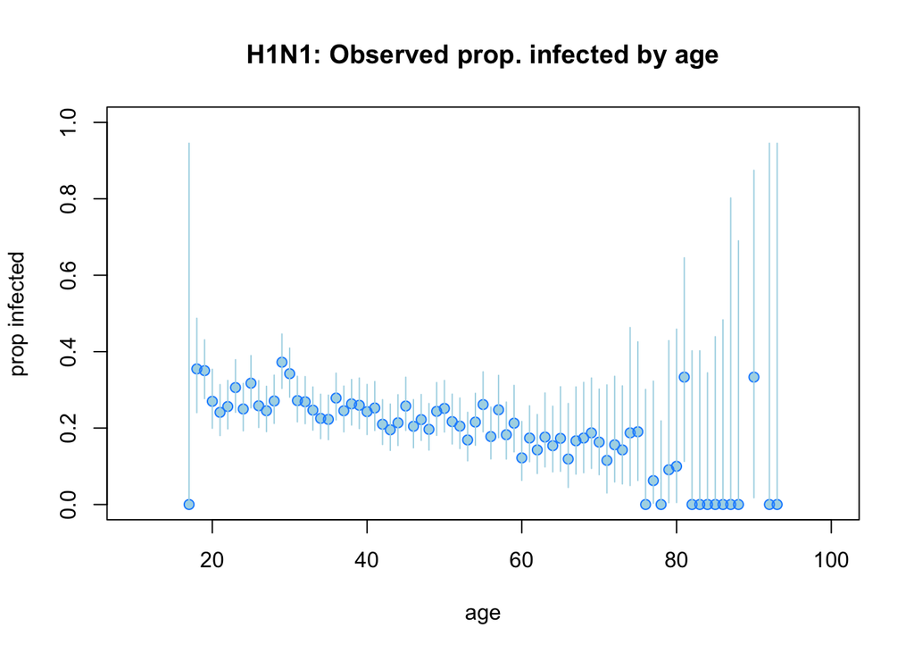

#### Visualize the relationship between age and prob of H3N2 infection

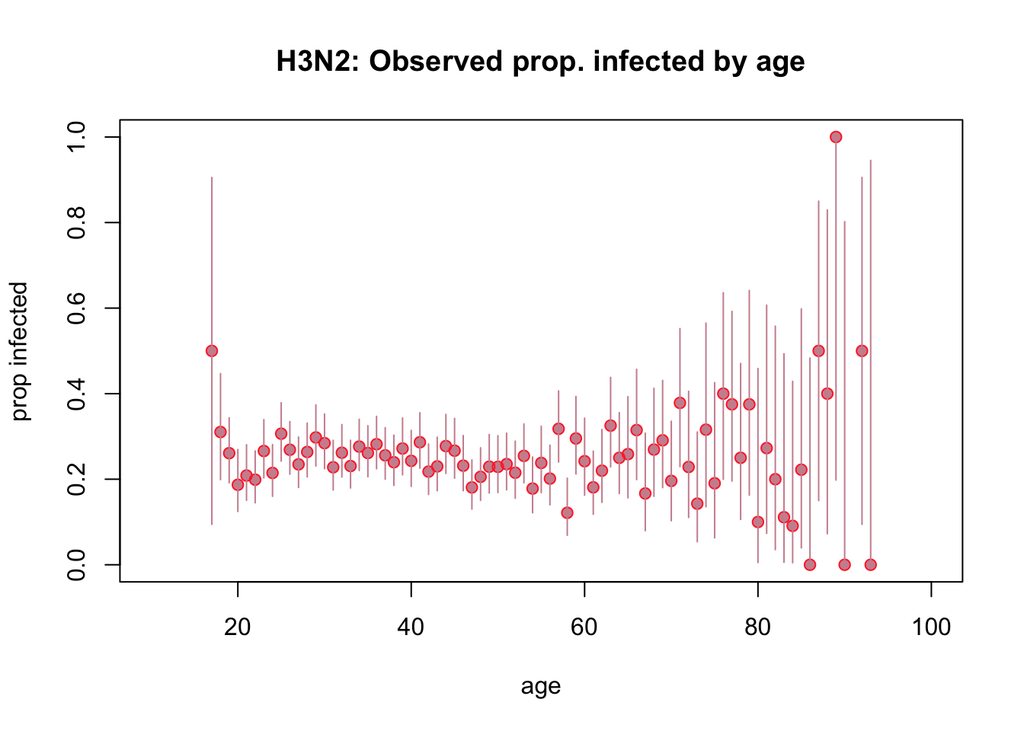

#### Visualize the relationship between country and prob infection

H1N1

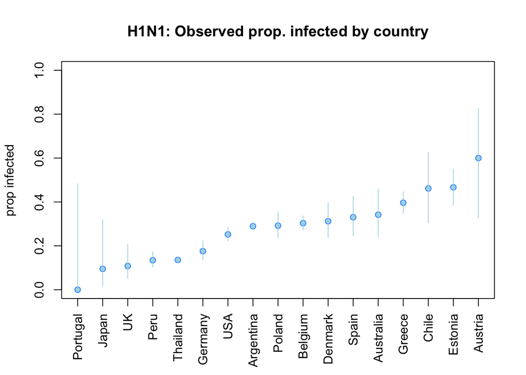

H3N2

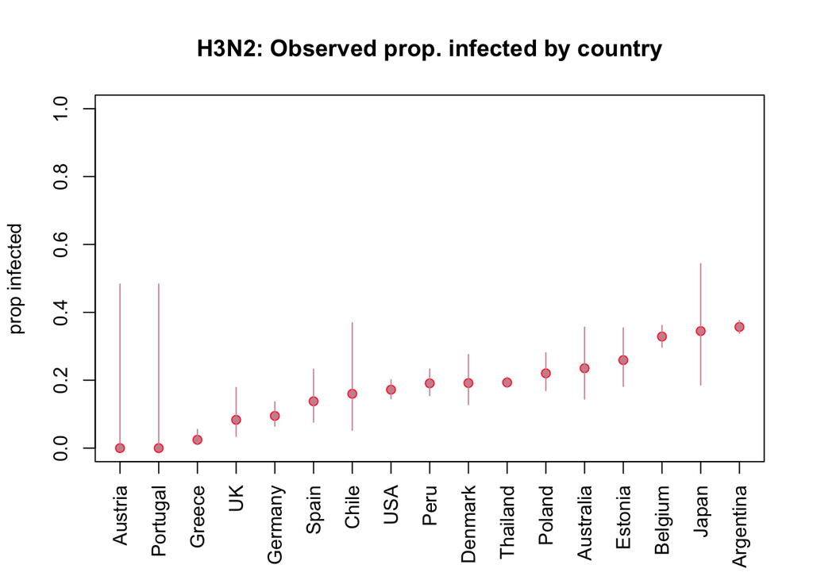

#### Visualize the relationship between season and prob infection

H1N1

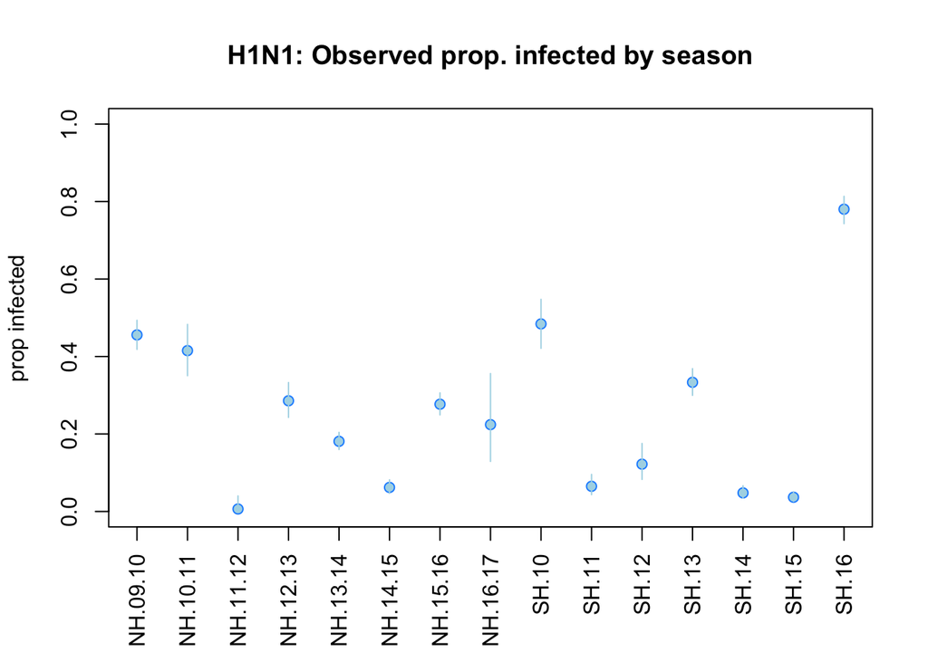

H3N2

[figure not shown]

### H1N1 10-fold CV

We know the relationship between age and probability of infection should be non-linear. Use cross-validation to verify, and to choose the number of degrees of freedom to include in a spline

### H3N2 10-fold CV

We know the relationship between age and probability of infection should be non-linear. Use cross-validation to verify, and to choose the number of degrees of freedom to include in a spline

## Set up a logistic regression that includes the following predictors:

- age
- imprinting status
- vaccination status
- antiviral use
- season
- country

### Clean data for fitting

```
##
## Argentina Australia   Austria   Belgium     Chile   Denmark   Estonia
##      2277        79        15       820        39       141       150
##   Germany    Greece     Japan      Peru    Poland  Portugal     Spain
##       313       395        21       387       250         6       112
##  Thailand        UK       USA
##      2510        74       817
```

```
## [1] 8406
```

### First fit a model where the only independent variable is age

Treat vaccination, antivial use, underlying symptoms, country and season as blocking variables with fixed effects

```r
library(splines)
library(ROCR)
```

```r
## H1N1 fit to country, season and medical history only (no effect of age or imprinting)
fit0 = glm(H1N1 ~ anyvac + anyav + anydx + country + season, data = train.H1N1, family = binomial)
summary(fit0)
```

```
##
## Call:
## glm(formula = H1N1 ~ anyvac + anyav + anydx + country + season,
##     family = binomial, data = train.H1N1)
##
## Deviance Residuals:
##     Min       1Q   Median       3Q      Max
## -2.3092  -0.6400  -0.3386  -0.1354   3.2007
##
## Coefficients:
##                  Estimate Std. Error z value Pr(>|z|)
## (Intercept)       0.55933    0.18214   3.071 0.002134 **
## anyvac1          -0.70204    0.08922  -7.868 3.59e-15 ***
## anyvac2           0.29160    0.55260   0.528 0.597707
## anyav1            0.85340    0.10887   7.839 4.55e-15 ***
## anydx1           -0.34122    0.07326  -4.657 3.20e-06 ***
## countryAustralia -0.71135    0.32607  -2.182 0.029138 *
## countryBelgium   -0.07771    0.17634  -0.441 0.659454
## countryChile      2.90202    0.49269   5.890 3.86e-09 ***
## countryDenmark   -0.40647    0.25592  -1.588 0.112231
## countryEstonia    0.07037    0.24068   0.292 0.769992
## countryGermany   -1.10614    0.23537  -4.700 2.61e-06 ***
## countryGreece    -0.44281    0.19546  -2.265 0.023486 *
## countryOther     -0.77745    0.45522  -1.708 0.087664 .
## countryPeru      -1.38027    0.19769  -6.982 2.91e-12 ***
## countryPoland    -0.52254    0.21991  -2.376 0.017492 *
## countrySpain     -0.88453    0.26034  -3.398 0.000680 ***
## countryThailand  -1.00810    0.14727  -6.845 7.65e-12 ***
## countryUK        -1.40669    0.41833  -3.363 0.000772 ***
## countryUSA       -0.59989    0.18072  -3.319 0.000902 ***
## seasonNH.10.11   -0.28470    0.18324  -1.554 0.120257
## seasonNH.11.12   -5.07557    1.01151  -5.018 5.23e-07 ***
## seasonNH.12.13   -0.93301    0.15883  -5.874 4.24e-09 ***
## seasonNH.13.14   -1.03806    0.13252  -7.833 4.75e-15 ***
## seasonNH.14.15   -2.40102    0.18713 -12.831  < 2e-16 ***
## seasonNH.15.16   -0.74711    0.12389  -6.030 1.64e-09 ***
## seasonNH.16.17   -0.79716    0.34269  -2.326 0.020007 *
## seasonSH.10       0.14359    0.20169   0.712 0.476503
## seasonSH.11      -3.83829    0.35721 -10.745  < 2e-16 ***
## seasonSH.12      -2.03699    0.28097  -7.250 4.17e-13 ***
## seasonSH.13      -0.86732    0.18375  -4.720 2.36e-06 ***
## seasonSH.14      -3.04827    0.24787 -12.298  < 2e-16 ***
## seasonSH.15      -3.17882    0.23823 -13.343  < 2e-16 ***
## seasonSH.16       1.02611    0.19290   5.319 1.04e-07 ***
## ---
## Signif. codes:  0 '***' 0.001 '**' 0.01 '*' 0.05 '.' 0.1 ' ' 1
##
## (Dispersion parameter for binomial family taken to be 1)
##
##     Null deviance: 8318.5  on 7565  degrees of freedom
## Residual deviance: 6171.5  on 7533  degrees of freedom
## AIC: 6237.5
##
## Number of Fisher Scoring iterations: 7
```

```r
## H1N1 fit to age only, plus fixed effects of vaccination, av use, underlying conditions, country and season
fit1 = glm(H1N1 ~ ns(age, knots = 65) + anyvac + anyav + anydx + country + season, data = train.H1N1, family = binomial)
summary(fit1)
```

```
##
## Call:
## glm(formula = H1N1 ~ ns(age, knots = 65) + anyvac + anyav + anydx +
##     country + season, family = binomial, data = train.H1N1)
##
## Deviance Residuals:
##     Min       1Q   Median       3Q      Max
## -2.3120  -0.6515  -0.3419  -0.1198   3.1900
##
## Coefficients:
##                      Estimate Std. Error z value Pr(>|z|)
## (Intercept)           0.51765    0.19133   2.706 0.006819 **
## ns(age, knots = 65)1 -0.65242    0.25492  -2.559 0.010488 *
## ns(age, knots = 65)2 -1.32798    0.44140  -3.009 0.002625 **
## anyvac1              -0.67533    0.09022  -7.485 7.13e-14 ***
## anyvac2               0.27057    0.55408   0.488 0.625317
## anyav1                0.85635    0.10892   7.862 3.78e-15 ***
## anydx1               -0.30041    0.07601  -3.952 7.75e-05 ***
## countryAustralia     -0.73744    0.32678  -2.257 0.024027 *
## countryBelgium       -0.07789    0.17683  -0.440 0.659580
## countryChile          2.87872    0.49349   5.833 5.43e-09 ***
## countryDenmark       -0.41444    0.25606  -1.619 0.105550
## countryEstonia        0.04747    0.24077   0.197 0.843717
## countryGermany       -1.14198    0.23574  -4.844 1.27e-06 ***
## countryGreece        -0.44097    0.19582  -2.252 0.024332 *
## countryOther         -0.80328    0.45433  -1.768 0.077056 .
## countryPeru          -1.40244    0.19783  -7.089 1.35e-12 ***
## countryPoland        -0.52250    0.22011  -2.374 0.017605 *
## countrySpain         -0.81450    0.26122  -3.118 0.001820 **
## countryThailand      -1.00254    0.14736  -6.804 1.02e-11 ***
## countryUK            -1.40203    0.41928  -3.344 0.000826 ***
## countryUSA           -0.61281    0.18137  -3.379 0.000728 ***
## seasonNH.10.11       -0.28504    0.18353  -1.553 0.120406
## seasonNH.11.12       -5.06502    1.01167  -5.007 5.54e-07 ***
## seasonNH.12.13       -0.92930    0.15991  -5.812 6.19e-09 ***
## seasonNH.13.14       -1.02931    0.13353  -7.709 1.27e-14 ***
## seasonNH.14.15       -2.39605    0.18765 -12.769  < 2e-16 ***
## seasonNH.15.16       -0.73350    0.12515  -5.861 4.60e-09 ***
## seasonNH.16.17       -0.78227    0.34364  -2.276 0.022822 *
## seasonSH.10           0.14213    0.20190   0.704 0.481463
## seasonSH.11          -3.82937    0.35743 -10.714  < 2e-16 ***
## seasonSH.12          -2.01998    0.28124  -7.182 6.85e-13 ***
## seasonSH.13          -0.85968    0.18425  -4.666 3.07e-06 ***
## seasonSH.14          -3.03422    0.24891 -12.190  < 2e-16 ***
## seasonSH.15          -3.15597    0.23860 -13.227  < 2e-16 ***
## seasonSH.16           1.04763    0.19386   5.404 6.52e-08 ***
## ---
## Signif. codes:  0 '***' 0.001 '**' 0.01 '*' 0.05 '.' 0.1 ' ' 1
##
## (Dispersion parameter for binomial family taken to be 1)
##
##     Null deviance: 8318.5  on 7565  degrees of freedom
## Residual deviance: 6160.5  on 7531  degrees of freedom
## AIC: 6230.5
##
## Number of Fisher Scoring iterations: 7
```

```r
## H1N1 fit to age plus imprinting, plus fixed effects of vaccination, av use, underlying conditions, country and season
fit2 = glm(H1N1 ~ ns(age, knots = 65) + p.g1.protection + anyvac + anyav + anydx + country + season, data = train.H1N1, family = binomial)
summary(fit2)
```

```
##
## Call:
## glm(formula = H1N1 ~ ns(age, knots = 65) + p.g1.protection +
##     anyvac + anyav + anydx + country + season, family = binomial,
##     data = train.H1N1)
##
## Deviance Residuals:
##     Min       1Q   Median       3Q      Max
## -2.3121  -0.6515  -0.3420  -0.1195   3.2016
##
## Coefficients:
##                      Estimate Std. Error z value Pr(>|z|)
## (Intercept)           0.48035    0.19374   2.479 0.013160 *
## ns(age, knots = 65)1 -0.94991    0.35376  -2.685 0.007249 **
## ns(age, knots = 65)2 -1.62171    0.50872  -3.188 0.001434 **
## p.g1.protection       0.16254    0.13296   1.223 0.221505
## anyvac1              -0.67331    0.09026  -7.460 8.65e-14 ***
## anyvac2               0.27611    0.55440   0.498 0.618462
## anyav1                0.85810    0.10894   7.877 3.35e-15 ***
## anydx1               -0.29993    0.07602  -3.945 7.97e-05 ***
## countryAustralia     -0.73712    0.32662  -2.257 0.024019 *
## countryBelgium       -0.08037    0.17682  -0.455 0.649433
## countryChile          2.87501    0.49324   5.829 5.58e-09 ***
## countryDenmark       -0.41652    0.25593  -1.627 0.103632
## countryEstonia        0.06221    0.24094   0.258 0.796241
## countryGermany       -1.14098    0.23578  -4.839 1.30e-06 ***
## countryGreece        -0.43869    0.19581  -2.240 0.025064 *
## countryOther         -0.80266    0.45420  -1.767 0.077193 .
## countryPeru          -1.40769    0.19797  -7.111 1.16e-12 ***
## countryPoland        -0.52634    0.22010  -2.391 0.016786 *
## countrySpain         -0.80388    0.26170  -3.072 0.002128 **
## countryThailand      -1.00113    0.14736  -6.794 1.09e-11 ***
## countryUK            -1.40016    0.41937  -3.339 0.000842 ***
## countryUSA           -0.61953    0.18146  -3.414 0.000640 ***
## seasonNH.10.11       -0.28856    0.18361  -1.572 0.116048
## seasonNH.11.12       -5.05245    1.01173  -4.994 5.92e-07 ***
## seasonNH.12.13       -0.91725    0.16019  -5.726 1.03e-08 ***
## seasonNH.13.14       -1.01674    0.13390  -7.593 3.12e-14 ***
## seasonNH.14.15       -2.37788    0.18818 -12.636  < 2e-16 ***
## seasonNH.15.16       -0.71275    0.12626  -5.645 1.65e-08 ***
## seasonNH.16.17       -0.76480    0.34368  -2.225 0.026061 *
## seasonSH.10           0.14337    0.20196   0.710 0.477782
## seasonSH.11          -3.82476    0.35747 -10.699  < 2e-16 ***
## seasonSH.12          -2.00499    0.28138  -7.126 1.04e-12 ***
## seasonSH.13          -0.85021    0.18440  -4.611 4.01e-06 ***
## seasonSH.14          -3.02405    0.24897 -12.146  < 2e-16 ***
## seasonSH.15          -3.14230    0.23884 -13.157  < 2e-16 ***
## seasonSH.16           1.06598    0.19449   5.481 4.23e-08 ***
## ---
## Signif. codes:  0 '***' 0.001 '**' 0.01 '*' 0.05 '.' 0.1 ' ' 1
##
## (Dispersion parameter for binomial family taken to be 1)
##
##     Null deviance: 8318.5  on 7565  degrees of freedom
## Residual deviance: 6159.0  on 7530  degrees of freedom
## AIC: 6231
##
## Number of Fisher Scoring iterations: 7
```

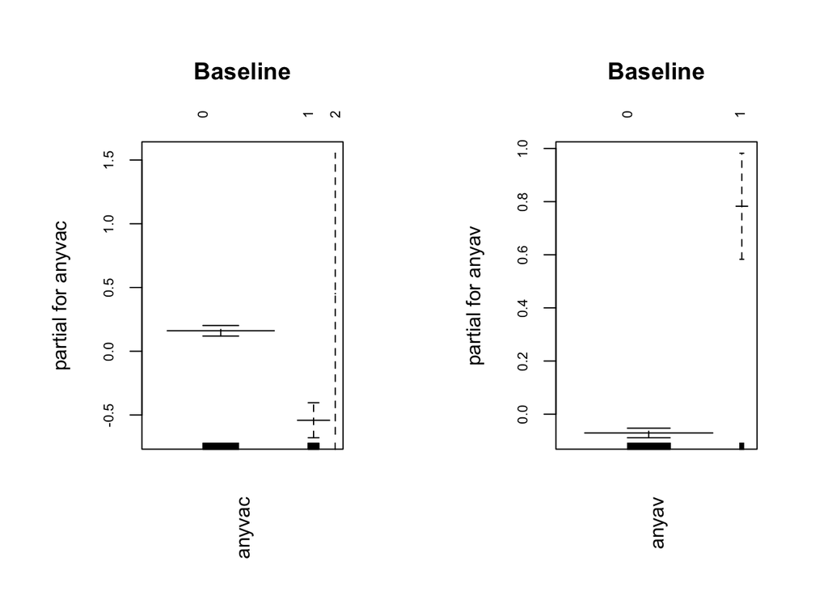

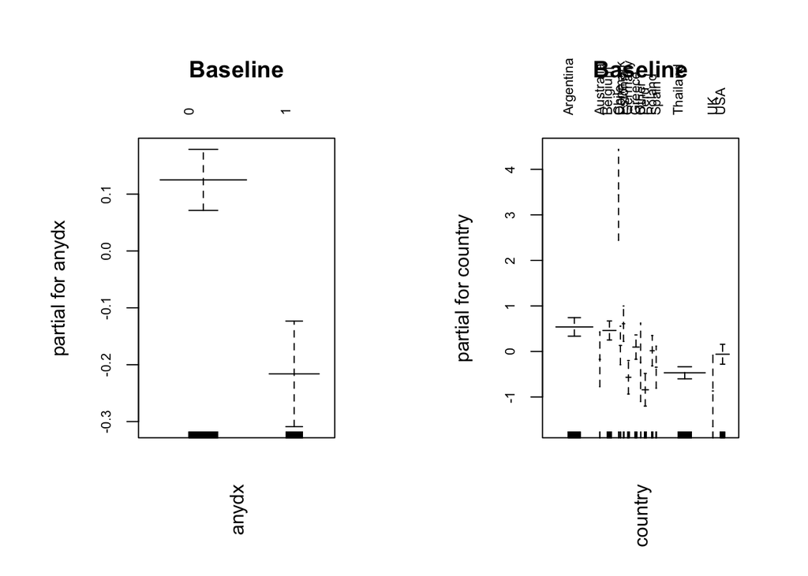

```r
## Plot the fits for each model side by side
par(mfrow = c(1, 2), las = 3, mar = c(6, 6, 6, 3), cex.axis = .7)
library(gam)
plot.gam(fit0, se = T, col = 'dodgerblue', main = 'Baseline')
```

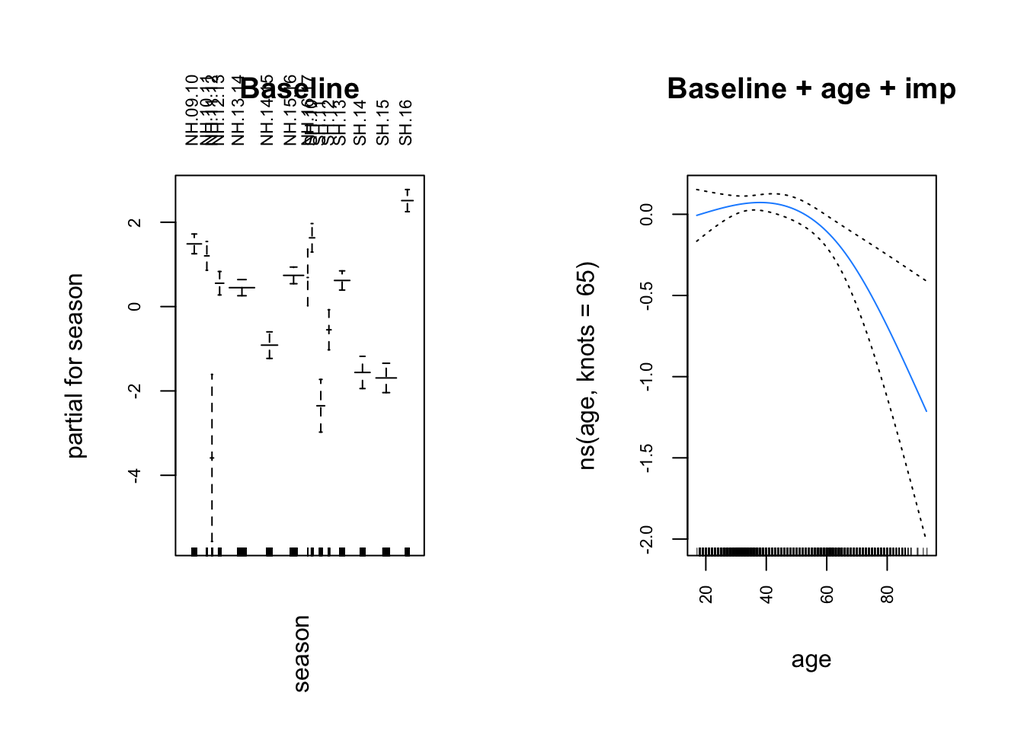

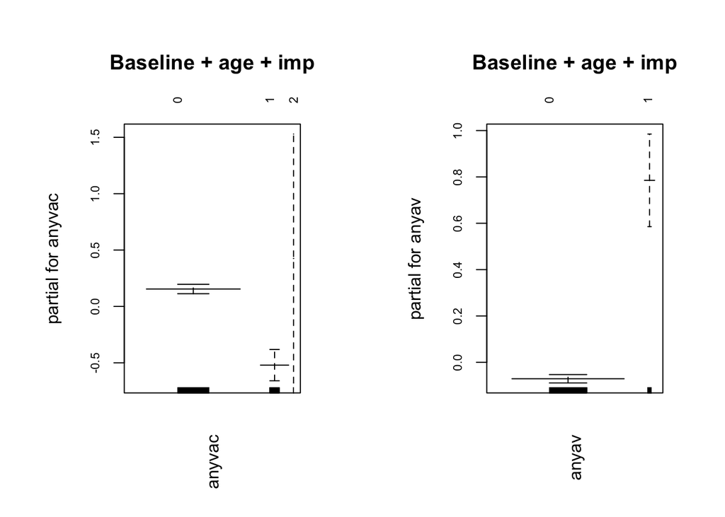

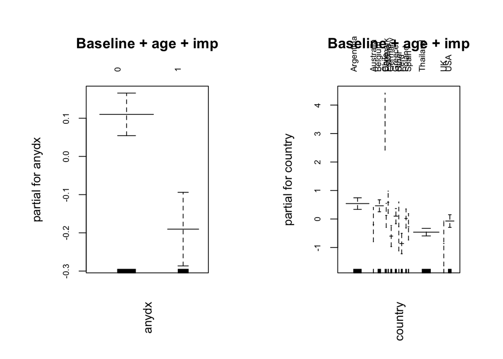

```r
plot.gam(fit1, se = T, col = 'dodgerblue', main = 'Baseline + age + imp')
```

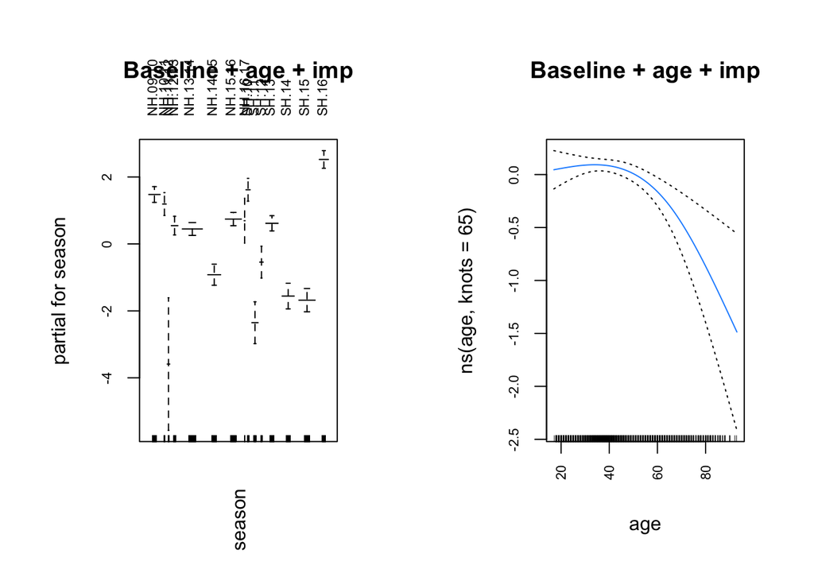

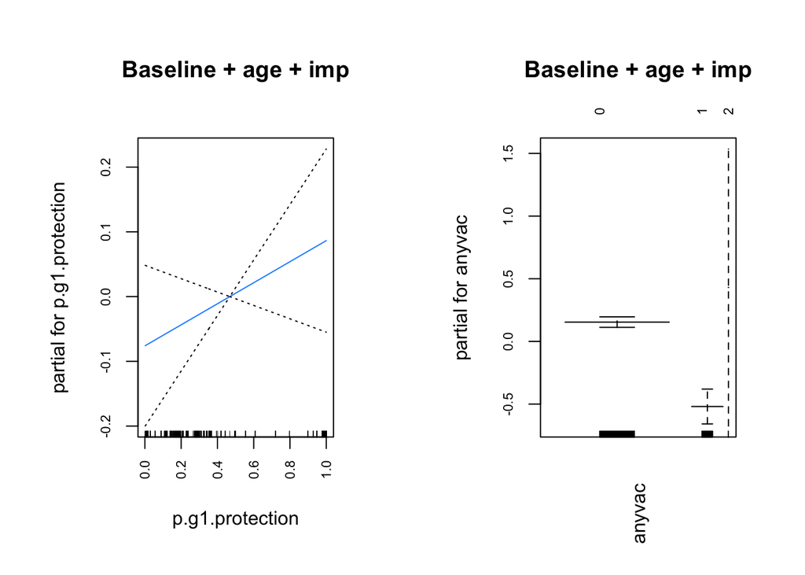

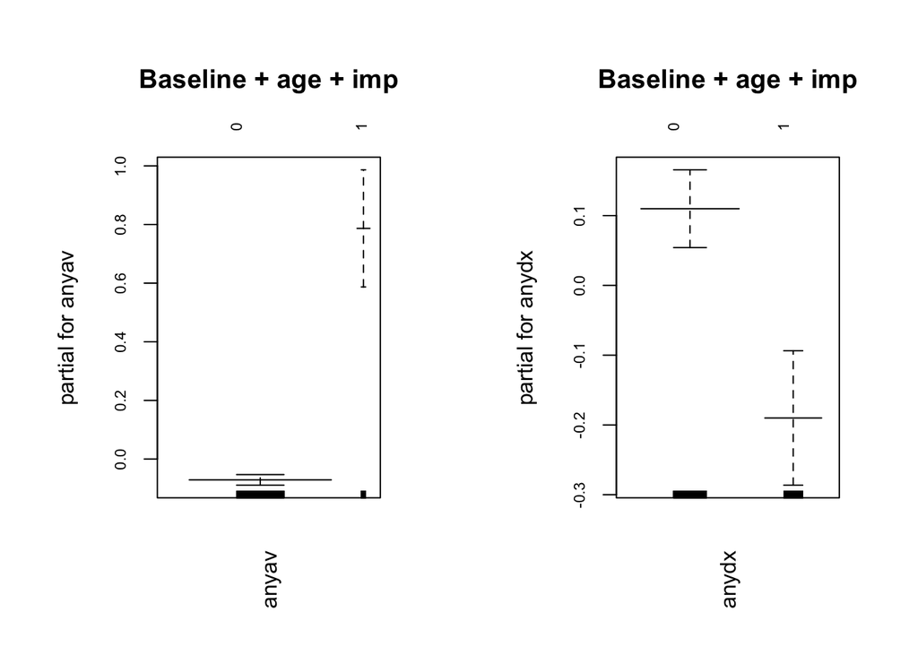

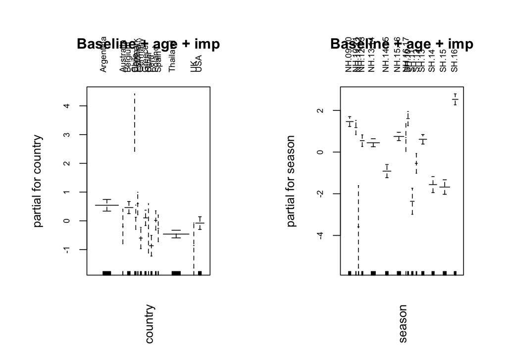

```r
plot.gam(fit2, se = T, col = 'dodgerblue', main = 'Baseline + age + imp')
```

```r
pdf('002Incidence_H1N1.pdf')
plot.gam(fit2, se = T, col = 'dodgerblue', main = 'Baseline + age + imp')
dev.off()
```

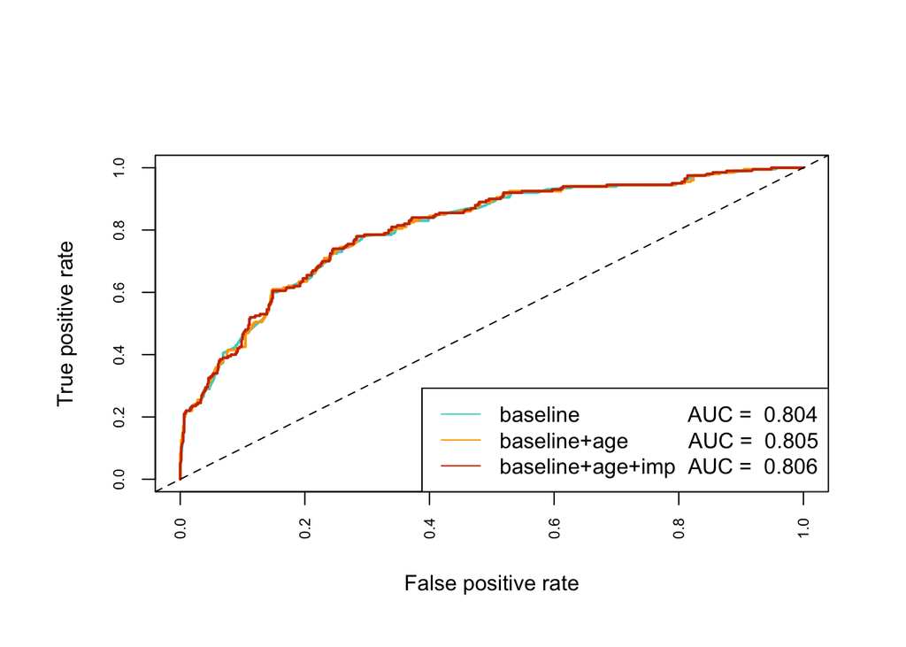

```r
## Test performance on test data
# Predict probs for each patient
probs0 = predict(fit0, newdata = test.H1N1, type = 'response')
probs1 = predict(fit1, newdata = test.H1N1, type = 'response')
probs2 = predict(fit2, newdata = test.H1N1, type = 'response')

# Create a predict object
pr0 = prediction(probs0, test.H1N1$H1N1)
pr1 = prediction(probs1, test.H1N1$H1N1)
pr2 = prediction(probs2, test.H1N1$H1N1)

# Assess tp and fp
prf0 = performance(pr0, measure = 'tpr', x.measure = 'fpr')
prf1 = performance(pr1, measure = 'tpr', x.measure = 'fpr')
prf2 = performance(pr2, measure = 'tpr', x.measure = 'fpr')

# Calculate AUCs
auc = sapply(list(pr0, pr1, pr2), FUN = function(xx){aa = performance(xx, measure = 'auc')
                                                                      round(aa@y.values[[1]], 3) })

# Plot AUC
par(mfrow = c(1,1))
plot(prf0, lwd = 2, col = cols[3])
plot(prf1, col = cols[2], add = TRUE, lwd = 2)
plot(prf2, col = cols[1], add = TRUE, lwd = 2)
abline(a = 0, b = 1, lty = 2)
legend('bottomright', paste(c('baseline                  AUC = ', 'baseline+age          AUC = ', 'baseline+age+imp  AUC = '), auc), col = cols[3:1], lty = 1)
```

```r
pdf('002Incidence_AUC_H1N1.pdf')
par(lwd = 3.5, cex = 1.5, cex.axis = 1.5, cex.lab = 1.5)
# Plot AUC
par(mfrow = c(1,1))
plot(prf0, col = cols[3])
plot(prf1, col = cols[2], add = TRUE)
plot(prf2, col = cols[1], add = TRUE)
abline(a = 0, b = 1)
legend('bottomright', paste(c('baseline                  AUC = ', 'baseline+age          AUC = ', 'baseline+age+imp  AUC = '), auc), col = cols[3:1], lty = 1, bty = 'n', cex = 1.5)
dev.off()
```

```r
# # Draw outcomes for each patient
# sim00 = sample(c(0,1), size = nrow(H1N1.model.dat), prob = c(.5, .5), replace = T)
# sim0 = sapply(X = pred0, FUN = function(pp) sample(c(0,1), size = 1, prob = c(1-pp, pp)))
# sim1 = sapply(X = pred1, FUN = function(pp) sample(c(0,1), size = 1, prob = c(1-pp, pp)))
# sim2 = sapply(X = pred2, FUN = function(pp) sample(c(0,1), size = 1, prob = c(1-pp, pp)))
#
# # Estimate the simulated error rate
# error.rt = numeric(4); names(error.rt) = c('coin.flip', 'baseline', 'baeline+age', 'baseline+age+imp')
# error.rt[1] = sum(abs(sim00 - H1N1.model.dat$H1N1))/nrow(H1N1.model.dat)
# error.rt[2] = sum(abs(sim0 - H1N1.model.dat$H1N1))/nrow(H1N1.model.dat)
# error.rt[3] = sum(abs(sim1 - H1N1.model.dat$H1N1))/nrow(H1N1.model.dat)
# error.rt[4] = sum(abs(sim2 - H1N1.model.dat$H1N1))/nrow(H1N1.model.dat)
# sort(error.rt)

# Calculate AUC for test data


AIC = c(fit0$aic, fit1$aic, fit2$aic); names(AIC) =  c('baseline', 'baeline+age', 'baseline+age+imp')
del.AIC = sort(AIC - min(AIC))
del.AIC
```

```
##      baeline+age baseline+age+imp         baseline
##        0.0000000        0.5007136        6.9904797
```

```r
load('master.AIC.table.H1N1.RData')
master.AIC.table['002Incidence', c('baseline', 'baseline+age', 'baseline+age+imp')] = AIC - min(AIC)
save(master.AIC.table, file = 'master.AIC.table.H1N1.RData')
rm(master.AIC.table)
```

### Clean H3N2 data for fitting

```
##
## Argentina Australia   Austria   Belgium     Chile   Denmark   Estonia
##      2516        68         6       851        25       120       108
##   Germany    Greece     Japan      Peru    Poland  Portugal     Spain
##       285       244        29       414       227         6        87
##  Thailand        UK       USA
##      2689        72       738
```

```
## [1] 8485
```

```r
## H3N2 fit to country, season and medical history only (no effect of age or imprinting)
fit0 = glm(H3N2 ~ anyvac + anyav + anydx + country + season, data = train.H3N2, family = binomial)
summary(fit0)
```

```
##
## Call:
## glm(formula = H3N2 ~ anyvac + anyav + anydx + country + season,
##     family = binomial, data = train.H3N2)
##
## Deviance Residuals:
##     Min       1Q   Median       3Q      Max
## -1.8007  -0.8058  -0.5572  -0.0001   2.5919
##
## Coefficients:
##                   Estimate Std. Error z value Pr(>|z|)
## (Intercept)      -16.44799  205.37041  -0.080  0.93617
## anyvac1           -0.33052    0.07197  -4.592 4.38e-06 ***
## anyvac2            0.18295    0.60334   0.303  0.76172
## anyav1             0.92991    0.11249   8.266  < 2e-16 ***
## anydx1            -0.17031    0.06275  -2.714  0.00664 **
## countryAustralia  -0.48181    0.32249  -1.494  0.13516
## countryBelgium    -0.31727    0.14087  -2.252  0.02431 *
## countryDenmark    -0.58741    0.27805  -2.113  0.03464 *
## countryEstonia    -0.38141    0.27134  -1.406  0.15982
## countryGermany    -1.22223    0.24663  -4.956 7.21e-07 ***
## countryGreece     -2.53404    0.47681  -5.315 1.07e-07 ***
## countryOther      -0.66456    0.35309  -1.882  0.05982 .
## countryPeru       -1.08429    0.15838  -6.846 7.59e-12 ***
## countryPoland     -0.59339    0.20396  -2.909  0.00362 **
## countrySpain      -1.60879    0.37257  -4.318 1.57e-05 ***
## countryThailand   -0.70925    0.08988  -7.891 3.01e-15 ***
## countryUK         -1.60540    0.44905  -3.575  0.00035 ***
## countryUSA        -0.90777    0.15648  -5.801 6.58e-09 ***
## seasonNH.10.11    15.00308  205.37060   0.073  0.94176
## seasonNH.11.12    16.69743  205.37043   0.081  0.93520
## seasonNH.12.13    16.26117  205.37041   0.079  0.93689
## seasonNH.13.14    15.37292  205.37040   0.075  0.94033
## seasonNH.14.15    16.39072  205.37039   0.080  0.93639
## seasonNH.15.16    15.23054  205.37042   0.074  0.94088
## seasonNH.16.17    17.45070  205.37049   0.085  0.93228
## seasonSH.10       15.18964  205.37053   0.074  0.94104
## seasonSH.11       16.04743  205.37042   0.078  0.93772
## seasonSH.12       15.55211  205.37047   0.076  0.93964
## seasonSH.13       15.04682  205.37043   0.073  0.94159
## seasonSH.14       16.13605  205.37041   0.079  0.93737
## seasonSH.15       15.99053  205.37041   0.078  0.93794
## seasonSH.16       16.91919  205.37045   0.082  0.93434
## ---
## Signif. codes:  0 '***' 0.001 '**' 0.01 '*' 0.05 '.' 0.1 ' ' 1
##
## (Dispersion parameter for binomial family taken to be 1)
##
##     Null deviance: 8564.4  on 7644  degrees of freedom
## Residual deviance: 7638.6  on 7613  degrees of freedom
## AIC: 7702.6
##
## Number of Fisher Scoring iterations: 16
```

```r
## H3N2 fit to age only, plus fixed effects of vaccination, av use, underlying conditions, country and season
fit1 = glm(H3N2 ~ ns(age, knots = 65) + anyvac + anyav + anydx + country + season, data = train.H3N2, family = binomial)
summary(fit1)
```

```
##
## Call:
## glm(formula = H3N2 ~ ns(age, knots = 65) + anyvac + anyav + anydx +
##     country + season, family = binomial, data = train.H3N2)
##
## Deviance Residuals:
##     Min       1Q   Median       3Q      Max
## -1.7951  -0.7994  -0.5524  -0.0001   2.6138
##
## Coefficients:
##                       Estimate Std. Error z value Pr(>|z|)
## (Intercept)          -16.45337  205.36525  -0.080 0.936144
## ns(age, knots = 65)1   0.27472    0.19752   1.391 0.164268
## ns(age, knots = 65)2   0.37376    0.28996   1.289 0.197390
## anyvac1               -0.34325    0.07254  -4.732 2.22e-06 ***
## anyvac2                0.17298    0.60359   0.287 0.774432
## anyav1                 0.92117    0.11269   8.174 2.98e-16 ***
## anydx1                -0.19673    0.06587  -2.987 0.002820 **
## countryAustralia      -0.47448    0.32249  -1.471 0.141206
## countryBelgium        -0.32795    0.14144  -2.319 0.020411 *
## countryDenmark        -0.59261    0.27800  -2.132 0.033034 *
## countryEstonia        -0.38002    0.27153  -1.400 0.161648
## countryGermany        -1.21169    0.24689  -4.908 9.21e-07 ***
## countryGreece         -2.54644    0.47724  -5.336 9.51e-08 ***
## countryOther          -0.64769    0.35285  -1.836 0.066419 .
## countryPeru           -1.07590    0.15849  -6.788 1.13e-11 ***
## countryPoland         -0.59294    0.20396  -2.907 0.003648 **
## countrySpain          -1.64766    0.37376  -4.408 1.04e-05 ***
## countryThailand       -0.71958    0.09021  -7.976 1.51e-15 ***
## countryUK             -1.62948    0.44953  -3.625 0.000289 ***
## countryUSA            -0.90227    0.15660  -5.762 8.34e-09 ***
## seasonNH.10.11        15.00162  205.36543   0.073 0.941768
## seasonNH.11.12        16.68806  205.36526   0.081 0.935235
## seasonNH.12.13        16.25151  205.36525   0.079 0.936926
## seasonNH.13.14        15.36404  205.36524   0.075 0.940363
## seasonNH.14.15        16.38156  205.36522   0.080 0.936422
## seasonNH.15.16        15.21804  205.36525   0.074 0.940929
## seasonNH.16.17        17.43586  205.36533   0.085 0.932340
## seasonSH.10           15.19538  205.36537   0.074 0.941017
## seasonSH.11           16.03439  205.36526   0.078 0.937766
## seasonSH.12           15.53913  205.36531   0.076 0.939685
## seasonSH.13           15.03635  205.36527   0.073 0.941633
## seasonSH.14           16.12500  205.36524   0.079 0.937415
## seasonSH.15           15.97687  205.36524   0.078 0.937989
## seasonSH.16           16.90642  205.36528   0.082 0.934389
## ---
## Signif. codes:  0 '***' 0.001 '**' 0.01 '*' 0.05 '.' 0.1 ' ' 1
##
## (Dispersion parameter for binomial family taken to be 1)
##
##     Null deviance: 8564.4  on 7644  degrees of freedom
## Residual deviance: 7636.0  on 7611  degrees of freedom
## AIC: 7704
##
## Number of Fisher Scoring iterations: 16
```

```r
## H3N2 fit to age plus imprinting, plus fixed effects of vaccination, av use, underlying conditions, country and season
fit2 = glm(H3N2 ~ ns(age, knots = 65) + p.g2.protection + anyvac + anyav + anydx + country + season, data = train.H3N2, family = binomial)
summary(fit2)
```

```
##
## Call:
## glm(formula = H3N2 ~ ns(age, knots = 65) + p.g2.protection +
##     anyvac + anyav + anydx + country + season, family = binomial,
##     data = train.H3N2)
##
## Deviance Residuals:
##     Min       1Q   Median       3Q      Max
## -1.8041  -0.7987  -0.5525  -0.0001   2.6040
##
## Coefficients:
##                       Estimate Std. Error z value Pr(>|z|)
## (Intercept)          -16.51096  205.37249  -0.080 0.935923
## ns(age, knots = 65)1   0.39503    0.27507   1.436 0.150976
## ns(age, knots = 65)2   0.47423    0.33047   1.435 0.151288
## p.g2.protection        0.07130    0.11349   0.628 0.529827
## anyvac1               -0.34393    0.07255  -4.741 2.13e-06 ***
## anyvac2                0.17632    0.60353   0.292 0.770179
## anyav1                 0.91925    0.11275   8.153 3.55e-16 ***
## anydx1                -0.19756    0.06589  -2.999 0.002712 **
## countryAustralia      -0.47348    0.32254  -1.468 0.142114
## countryBelgium        -0.32713    0.14146  -2.313 0.020745 *
## countryDenmark        -0.58984    0.27812  -2.121 0.033940 *
## countryEstonia        -0.38470    0.27166  -1.416 0.156746
## countryGermany        -1.21034    0.24691  -4.902 9.49e-07 ***
## countryGreece         -2.54696    0.47721  -5.337 9.44e-08 ***
## countryOther          -0.65110    0.35307  -1.844 0.065164 .
## countryPeru           -1.07102    0.15865  -6.751 1.47e-11 ***
## countryPoland         -0.59196    0.20398  -2.902 0.003706 **
## countrySpain          -1.65065    0.37387  -4.415 1.01e-05 ***
## countryThailand       -0.71974    0.09022  -7.978 1.49e-15 ***
## countryUK             -1.63247    0.44964  -3.631 0.000283 ***
## countryUSA            -0.89751    0.15677  -5.725 1.03e-08 ***
## seasonNH.10.11        15.00097  205.37265   0.073 0.941772
## seasonNH.11.12        16.68248  205.37248   0.081 0.935259
## seasonNH.12.13        16.24622  205.37247   0.079 0.936948
## seasonNH.13.14        15.35874  205.37245   0.075 0.940386
## seasonNH.14.15        16.37369  205.37244   0.080 0.936455
## seasonNH.15.16        15.20923  205.37247   0.074 0.940965
## seasonNH.16.17        17.43065  205.37255   0.085 0.932362
## seasonSH.10           15.19481  205.37258   0.074 0.941021
## seasonSH.11           16.03258  205.37248   0.078 0.937776
## seasonSH.12           15.53328  205.37252   0.076 0.939710
## seasonSH.13           15.03186  205.37249   0.073 0.941652
## seasonSH.14           16.12140  205.37246   0.078 0.937432
## seasonSH.15           15.97182  205.37246   0.078 0.938011
## seasonSH.16           16.89903  205.37250   0.082 0.934420
## ---
## Signif. codes:  0 '***' 0.001 '**' 0.01 '*' 0.05 '.' 0.1 ' ' 1
##
## (Dispersion parameter for binomial family taken to be 1)
##
##     Null deviance: 8564.4  on 7644  degrees of freedom
## Residual deviance: 7635.6  on 7610  degrees of freedom
## AIC: 7705.6
##
## Number of Fisher Scoring iterations: 16
```

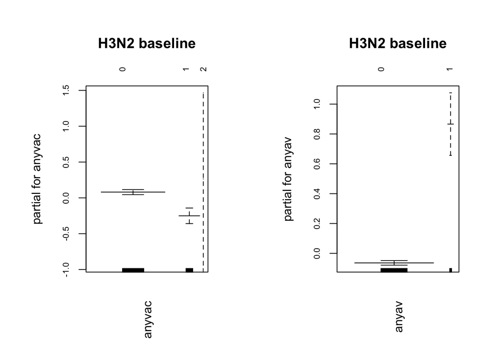

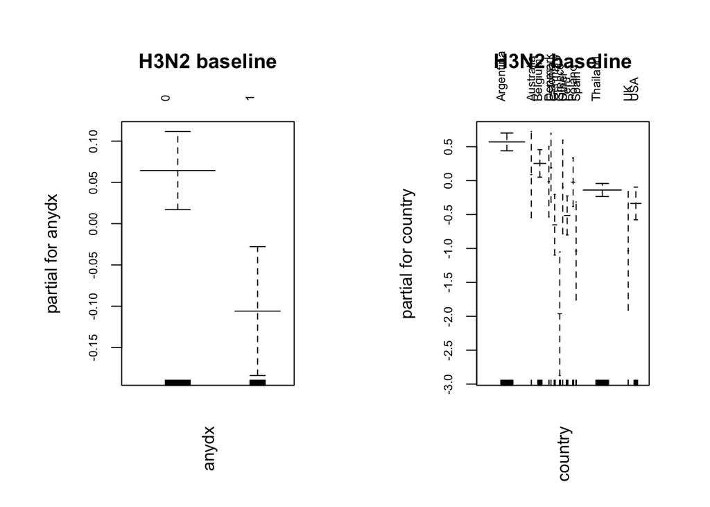

```r
## Plot the fits for each model side by side
par(mfrow = c(1, 2), las = 3, mar = c(6, 6, 6, 3), cex.axis = .7)
library(gam)
plot.gam(fit0, se = T, col = 'firebrick1', main = 'H3N2 baseline')
```

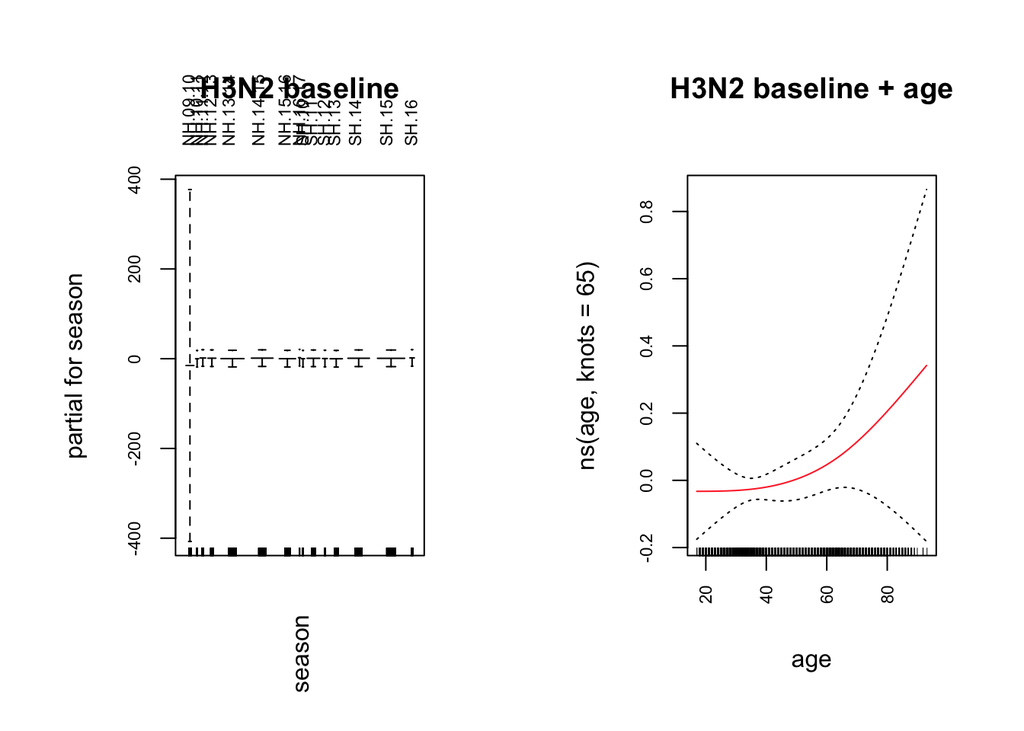

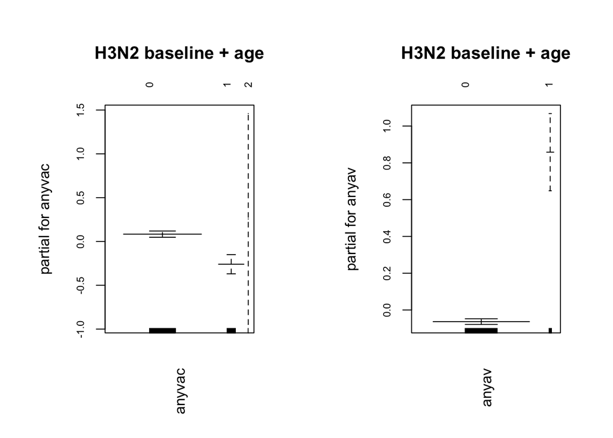

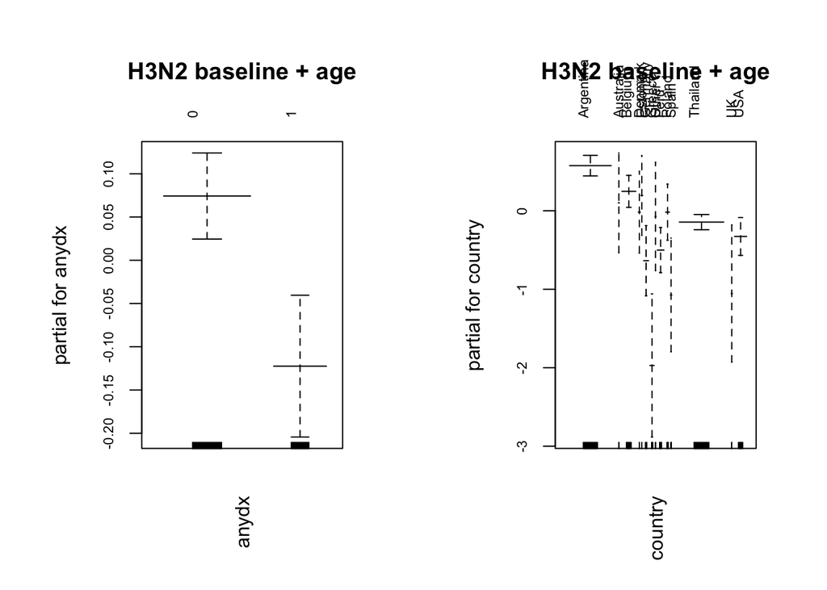

```r
plot.gam(fit1, se = T, col = 'firebrick1', main = 'H3N2 baseline + age')
```

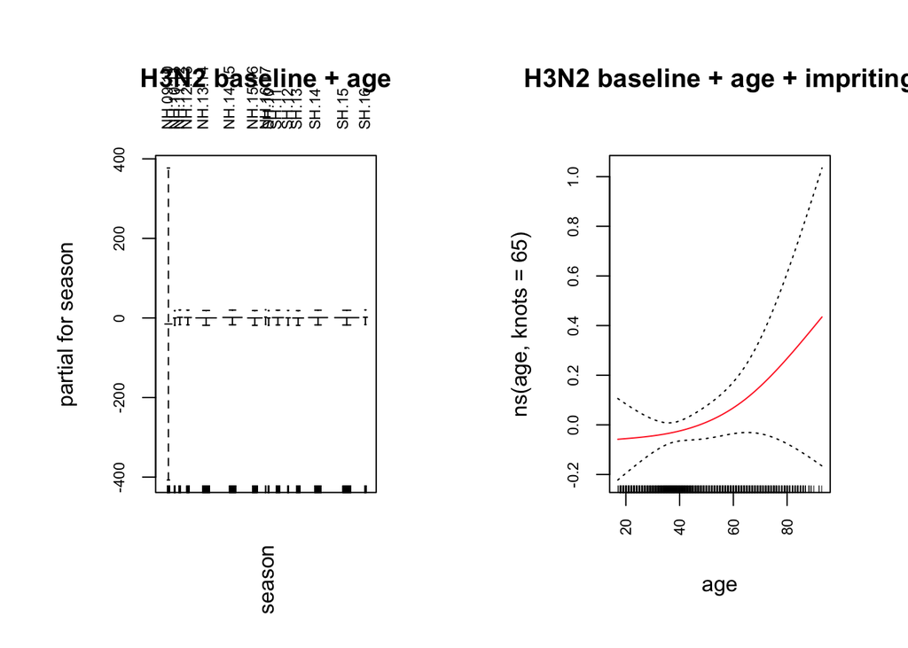

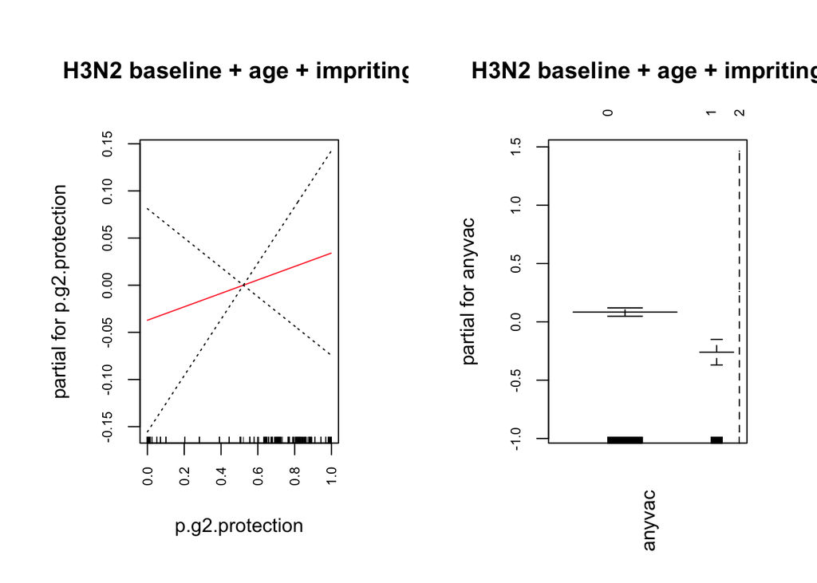

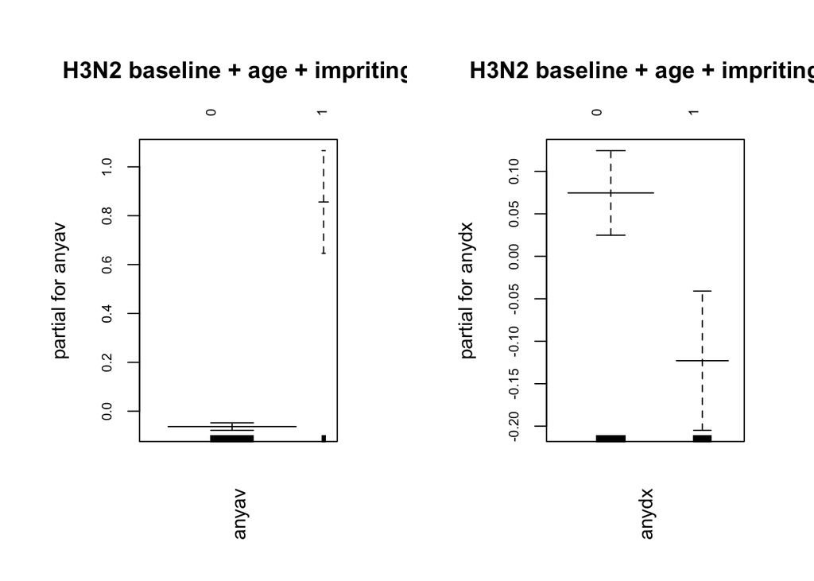

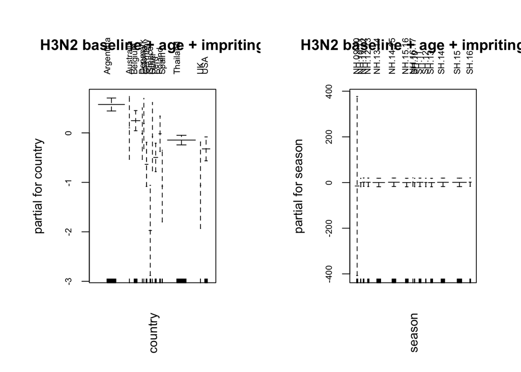

```r
plot.gam(fit2, se = T, col = 'firebrick1', main = 'H3N2 baseline + age + impriting')
```

```r
pdf('002Incidence_H3N2.pdf')
plot.gam(fit2, se = T, col = 'firebrick1', main = 'H3N2 baseline + age + impriting')
dev.off()
```

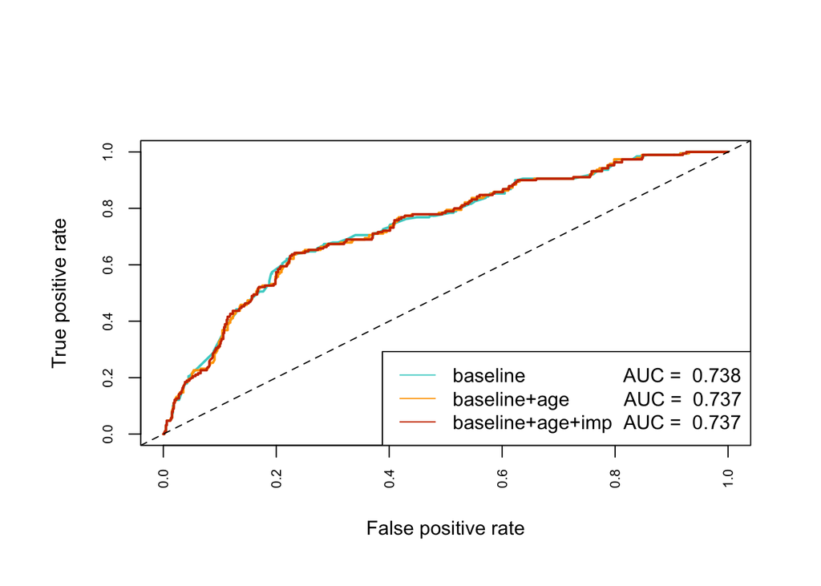

```r
## Test performance on test data
# Predict probs for each patient
probs0 = predict(fit0, newdata = test.H3N2, type = 'response')
probs1 = predict(fit1, newdata = test.H3N2, type = 'response')
probs2 = predict(fit2, newdata = test.H3N2, type = 'response')

# Create a predict object
pr0 = prediction(probs0, test.H3N2$H3N2)
pr1 = prediction(probs1, test.H3N2$H3N2)
pr2 = prediction(probs2, test.H3N2$H3N2)

# Assess tp and fp
prf0 = performance(pr0, measure = 'tpr', x.measure = 'fpr')
prf1 = performance(pr1, measure = 'tpr', x.measure = 'fpr')
prf2 = performance(pr2, measure = 'tpr', x.measure = 'fpr')

# Calculate AUCs
auc = sapply(list(pr0, pr1, pr2), FUN = function(xx){aa = performance(xx, measure = 'auc')
                                                                      round(aa@y.values[[1]], 3) })

# Plot AUC
par(mfrow = c(1,1))
plot(prf0, lwd = 2, col = cols[3])
plot(prf1, col = cols[2], add = TRUE, lwd = 2)
plot(prf2, col = cols[1], add = TRUE, lwd = 2)
abline(a = 0, b = 1, lty = 2)
legend('bottomright', paste(c('baseline                  AUC = ', 'baseline+age          AUC = ', 'baseline+age+imp  AUC = '), auc), col = cols[3:1], lty = 1)
```

```r
pdf('002Incidence_AUC_H3N2.pdf')
par(lwd = 3.5, cex = 1.5, cex.axis = 1.5, cex.lab = 1.5)
# Plot AUC
par(mfrow = c(1,1))
plot(prf0, col = cols[3])
plot(prf1, col = cols[2], add = TRUE)
plot(prf2, col = cols[1], add = TRUE)
abline(a = 0, b = 1)
legend('bottomright', paste(c('baseline                  AUC = ', 'baseline+age          AUC = ', 'baseline+age+imp  AUC = '), auc), col = cols[3:1], lty = 1, bty = 'n', cex = 1.5)
dev.off()
```

```r
# # Predict probs for each patient
# pred0 = predict(fit0, type = 'response')
# pred1 = predict(fit1, type = 'response')
# pred2 = predict(fit2, type = 'response')
#
# # Draw outcomes for each patient
# sim00 = sample(c(0,1), size = nrow(H3N2.model.dat), prob = c(.5, .5), replace = T)
# sim0 = sapply(X = pred0, FUN = function(pp) sample(c(0,1), size = 1, prob = c(1-pp, pp)))
# sim1 = sapply(X = pred1, FUN = function(pp) sample(c(0,1), size = 1, prob = c(1-pp, pp)))
# sim2 = sapply(X = pred2, FUN = function(pp) sample(c(0,1), size = 1, prob = c(1-pp, pp)))
#
# # Estimate the simulated error rate
# error.rt = numeric(4); names(error.rt) = c('coin.flip', 'baseline', 'baeline+age', 'baseline+age+imp')
# error.rt[1] = sum(abs(sim00 - H3N2.model.dat$H3N2))/nrow(H3N2.model.dat)
# error.rt[2] = sum(abs(sim0 - H3N2.model.dat$H3N2))/nrow(H3N2.model.dat)
# error.rt[3] = sum(abs(sim1 - H3N2.model.dat$H3N2))/nrow(H3N2.model.dat)
# error.rt[4] = sum(abs(sim2 - H3N2.model.dat$H3N2))/nrow(H3N2.model.dat)
# sort(error.rt)

AIC = c(fit0$aic, fit1$aic, fit2$aic); names(AIC) =  c('baseline', 'baseline+age', 'baseline+age+imp')
del.AIC = sort(AIC - min(AIC))
del.AIC
```

```
##         baseline     baseline+age baseline+age+imp
##         0.000000         1.367424         2.973202
```

```r
# master.AIC.table = matrix(NA, ncol = 6, nrow = 7, dimnames = list(c('002Incidence', '002Prolonged', '003Symdur', '003Hospdays', '003ICU', '003Tothospdays', '003Death'), c('baseline', 'baseline+age', 'baseline+age+imp', 'simple.baseline', 'simple.baseline+age', 'simple.baseline+age+imp')))
# save(master.AIC.table, file = 'master.AIC.table.RData')

load('master.AIC.table.H3N2.RData')
master.AIC.table['002Incidence', c('baseline', 'baseline+age', 'baseline+age+imp')] = AIC - min(AIC)
save(master.AIC.table, file = 'master.AIC.table.H3N2.RData')
rm(master.AIC.table)
```